# Access to Transportation: Bus Network and Spatial Inequality in Columbus

Eungang (Peter) Choi

8/10/2019

# Introduction

In the city of Columbus, there is a clear spatial divide that exists based on class and status. Is this spatial inequality linked to the access the people in each neighborhood have to various infrastructure in the city? This is the question that this study seeks to answer.

## Research Questions

**What is the relationship between the bus network and spatial inequality in Columbus?**

- Income levels
- Low access (food deserts)
- Race

# Data & Methods

## Bus Stop Data

Source: [Smart Columbus Data](https://smartcolumbusos.com)

COTA Bus stop data (Sept. 2018)

- geocodes
- bus lines passing through the stop

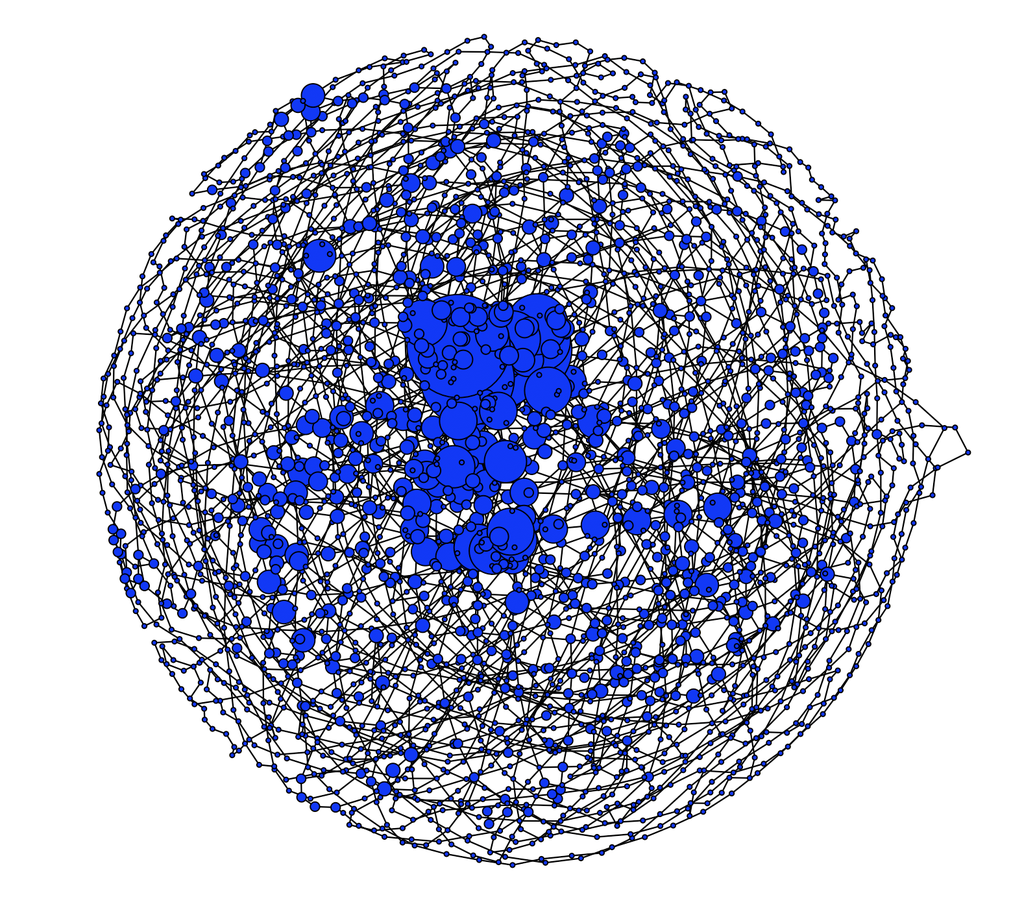

## Create Network

1. Arrange the stops by each lines
2. Connect the stops (*nodes*) in each lines (forming *ties*)
3. Calculate *Centrality*

**Centrality**

- Measuring the importance of a node
- Having the most ties to other actors in the network
- More access to other parts of the city

[interactive chart not shown]

## Aggregate by Tracts

$$\textrm{Tract Centrality} = \frac{\textrm{Sum of centrality scores in all the bus stops in each tract}}{\textrm{Number of bus stops in each tract}}$$

## Food Access Research Atlas Data

Source: [USDA](https://www.ers.usda.gov/data-products/food-access-research-atlas/)

- tract-level data on food access (supermarket accessibility)
- Low income
- low vehicle access
- by various demographic groups (race, age)

## Key Variables

- **Median Family Income**: tract median family income (standardized)
- **Low Access Vehicles**: more than 100 households without vehicles & beyond 1/2 mile from supermarket
- **Low Access Population(%)**: Share of Low Access(1/2 mile) population in tract
- **Low Access Whites(%)**: Share of Low Access(1/2 mile) Whites in tract population
- **Low Access Blacks(%)**: Share of Low Access(1/2 mile) Blacks in tract population
- **Low Access Hispanics(%)**: Share of Low Access(1/2 mile) Hispanics in tract population
- **Low Access Asians(%)**: Share of Low Access(1/2 mile) Asians in tract population

# Results

[interactive chart not shown]

## Model 1: Income

Income alone has no significant association with the centrality of tracts.

## Model 2: Income + Low Access

Here, all three variables are significantly associated with the centrality of the tract. Results indicates that centrality increases as median family income increases. Centrality is also higher for areas where there are more people without vehicles in the household. However, centrality decreases as the share of low access population increases in a population. Tracts that have low vehicle accessibility have better access to other parts of the city than other tracts. However, as the share of low access population in a tract increases, the tract will be more isolated.

## Model 3: Income + Low Access + Racial Composition

To have a further look at why the share of low access population is negatively associated with the tract’s centrality, I break the low access population by race. Results indicate that the negative association between low access population and centrality is mainly driven by Whites and Black populations.

# Conclusion

## Limitations

- Causality:
  - Are the bus stops exacerbating spatial inequality
  - Is inequality shaping the bus lines?
- Divide between residential/industrial areas
- Usage (# of passengers)

## Contributions

- Use of public data
- Network of transportation
- Evaluation tool for cities

## Next Steps

- Two-mode networks
- Application in other cities